# Price Analysis of Airbnb in Paris

**1. INTRODUCTION**

Visiting Paris is always a good idea. The city of light makes for a dreamy getaway, and its diverse culture always provide tourists a brand-new experience on each visit. However, when it comes to accommodation, Paris is a little pricey. Thanks to Airbnb, a new affordable options appeared since 2008. More and more people choose to stay in a local house when they are travelling. The prices of the houses vary a lot depending on the location, the size, the service or the surroundings of the houses.

In this project, by working on the dataset of Airbnb in Paris, we studied, analyzed the data in order to conduct a simple descriptive analysis. Focusing on the price of the rental, we tried to find the mechanics of price determination.

The open sources of Airbnb in Paris:http://insideairbnb.com/paris/#

```r
library(readr)
library(tidyverse)
```

```r
library(dplyr)
library(ggplot2)
library(grid)
library(viridis)
library(plotly)
library(gganimate)
library(ggrepel)
library(cowplot)
library(gifski)
library(png)
library(hrbrthemes)
```

**2. OVERVIEW OF DATA SET**

First, let’s take a look on the variables that we got in the data set listing:

```r
setwd("~/Documents/R/Assignment 1 ")
paris_airbnb <- read_csv("~/Documents/R/Assignment 1 /paris_airbnb_listing.csv")
```

The data set contains 18 variables and 49255 observations. Each row is the descriptions of a Airbnb rental by different modality such as: room type, price, availability, etc, including also the names and the id of hosts. By observing quickly, we can see that there are some variables which contains missing values. For having a easier processing of data set, we would like to convert two columns that are character type to categorical type: “neighbourhood” and “room_type”.

```r
paris_airbnb$room_type <- as.factor(paris_airbnb$room_type)
paris_airbnb$neighbourhood <- as.factor(paris_airbnb$neighbourhood)
```

**3. EARLY DATA EXPLORATION**

**3.1 Data selection In order to effectively analyse the mechanism of the price, we have to know if there is any missing values or outliers in the data.**

```r
paris_airbnb <- select(paris_airbnb, -id, -name, -neighbourhood_group, -last_review, -license, -calculated_host_listings_count, reviews_per_month) #Remove columns
```

**3.2 Missing values**

In the dataset, some of fields in different variables contains missing values. As we couldn’t delete the whole variables, it might deviate the result. Therefore, “na.omit()” is used to remove all the missing values.

```r
paris_airbnb <- paris_airbnb %>% na.omit()  #Remove the NaN values from the dataset
```

**3.3 Outlier studies**

In this section, we would like to know if there are any extreme values in the data set. For a better visualization, the box plots is applied.

In the price’s box plot, the maximum values was 9000 euros while the minimum is 0. Since it is not possible to rent the apartment in 0 and to avoid the large deviation of the mean value of price per night, we decide to keep the price is larger than 0 euro and less than 3000 euros.

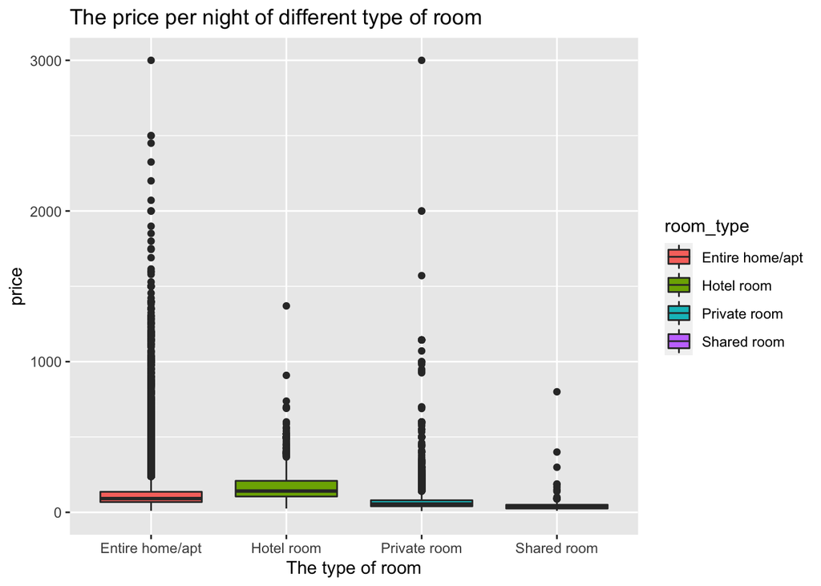

```r
paris_airbnb %>%
  ggplot(aes(x= room_type , y = price, fill = room_type)) + geom_boxplot() +
  ylim(1, 3000) +
  ggtitle("The price per night of different type of room") + xlab("The type of room")
```

```r
paris_airbnb <- filter(paris_airbnb, price <=3000, price >=1)
```

In the minimum night box plot, the value of 10_000 minimum night is a potentially outliners as it would not happen in reality. Because of that reason, we decided to keep only the rentals which the requirement of minimum nights are less than or equal to 2 years (700 days).

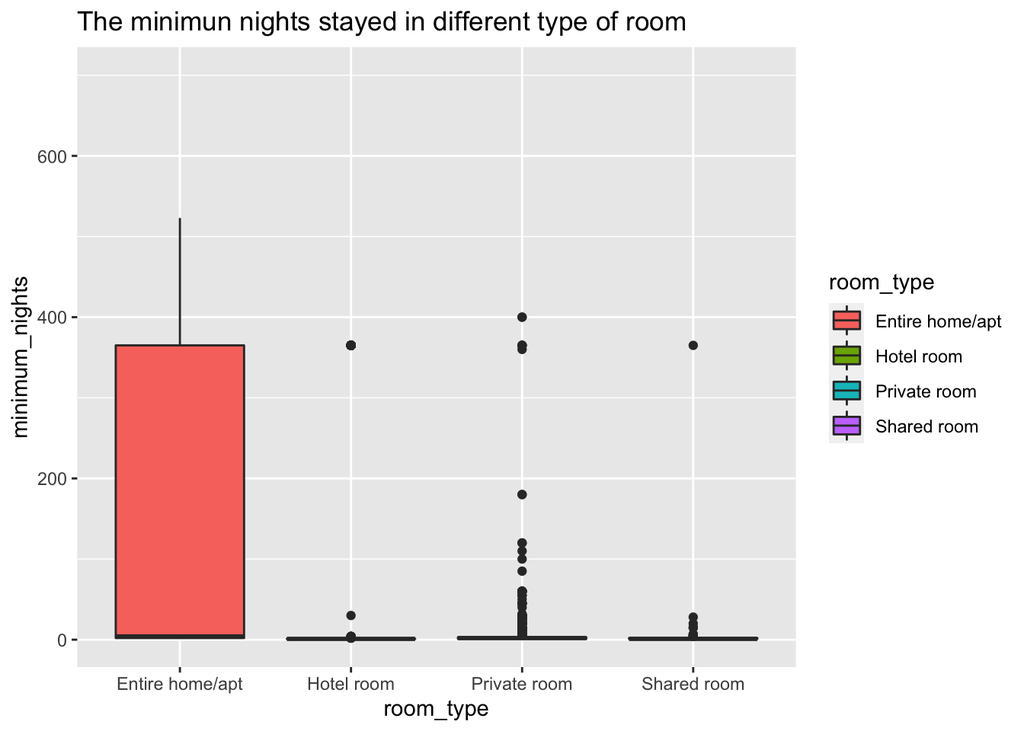

```r
paris_airbnb %>%
  ggplot(aes(x= room_type , y = minimum_nights, fill = room_type)) + geom_boxplot() +
  ylim(1, 700) +
  ggtitle("The minimun nights stayed in different type of room")
```

```r
paris_airbnb <- filter(paris_airbnb, minimum_nights <=700, minimum_nights >=1)
```

**3.4 The price distribution by district**

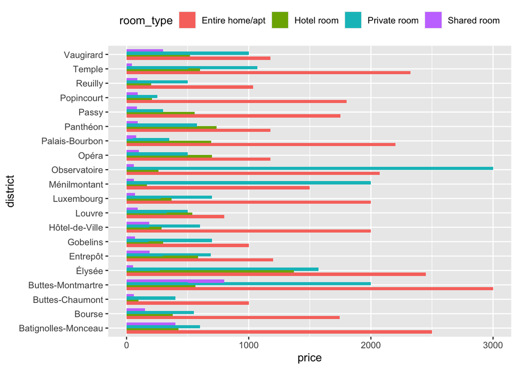

```r
paris_airbnb %>%
  ggplot(aes(x = price, y = neighbourhood, fill = room_type)) +
  geom_col(position = position_dodge(0.7)) +
  theme(legend.position = "top") +
  ylab("district")
```

**4. Save the data set**

```r
save(paris_airbnb, file = "paris_airbnb_analysis.RData")
```